# Checkpoint 2 report

Jim Milks

6/21/2021

```r
knitr::opts_chunk$set(echo = TRUE)
library(tidytext)
library(tidyr)
library(sentimentr)
library(lexicon)
library(stringr)
library(stringi)
library(dplyr)
library(ggplot2)
library(igraph)
library(forcats)
library(kableExtra)
data("stop_words")
data("profanity_alvarez")
data("profanity_racist")
profanity <- data.frame(word = profanity_alvarez)
racist <- data.frame(word = profanity_racist)
remove_words <- rbind(profanity, racist)
setwd("~/Desktop/Data_science/predictive_text/")
options(scipen = 1)
```

## Summary

This report is milestone report for week 2 of the John Hopkins University/Coursera Data Science capstone project. The objective of this report is to understand the basic statistical properties of the data sets, to report major/interesting features, and get feedback on initial plans for the predictive model.

The data comes from three sources of provided text data:

1. blogs
2. news
3. Twitter

I selected the English language text data out of the four possible languages and unified the data into a single corpus. The remainder of this report will focus on the properties of the English language data.

```r
con <- file("final/en_US/en_US.blogs.txt", open = "r")
blogs <- readLines(con, encoding = "UTF-8", skipNul = TRUE)
close(con)

#news data
con <- file("final/en_US/en_US.news.txt", open = "r")
news <- readLines(con, encoding = "UTF-8", skipNul = TRUE)
close(con)

#twitter data
con <- file("final/en_US/en_US.twitter.txt", open = "r")
twit <- readLines(con, skipNul = TRUE, encoding = "UTF-8")
close(con)
rm(con)

#Turn into tidy data
blogs_df <- tibble(text = blogs)
blogs_df$source <- rep("blog", length.out = length(blogs_df))
blogs_df$source = as.factor(blogs_df$source)
news_df <- tibble(text = news)
news_df$source <- rep("news", length.out = length(news_df))
news_df$source <- as.factor(news_df$source)
twit_df <- tibble(text = twit)
twit_df$source <- rep("twitter", length.out = length(twit_df))
twit_df$source <- as.factor(twit_df$source)

corpus <- rbind(blogs_df, news_df, twit_df)
```

## Summary Statistics

| Source | Characters | Words | Lines | Min | Mean | Max |
| --- | --- | --- | --- | --- | --- | --- |
| Blogs | 206824505 | 37570839 | 899288 | 0 | 42 | 6726 |
| News | 203223159 | 34494539 | 1010242 | 1 | 34 | 1796 |
| Twitter | 162096241 | 30451170 | 2360148 | 1 | 13 | 47 |

The data sets for this project are quite large. The Blog data set consists of 206824505 characters in 37570839 words and 899288 lines. The News data set has 203223159 characters in 34494539 words and 1010242 lines. The smallest of the three data sets, from Twitter, has “only” 162096241 characters, 30451170 words, and 2360148 lines. The words per line varies widely between the data sets, from a minimum of 0 to a maximum of 6726 for Blogs whereas the Twitter data set only has a maximum of 47 words per line. Not surprisingly, the mean words per line also varies widely, from the Blog data set mean of 42 down to the Twitter data set mean of 13.

```r
rm(words_per_line)
rm(number_of_lines)
rm(number_words)
rm(characters)
rm(blogs)
rm(news)
rm(twit)
rm(twit_df)
rm(blogs_df)
rm(news_df)
invisible(gc(verbose = FALSE, reset = TRUE))
```

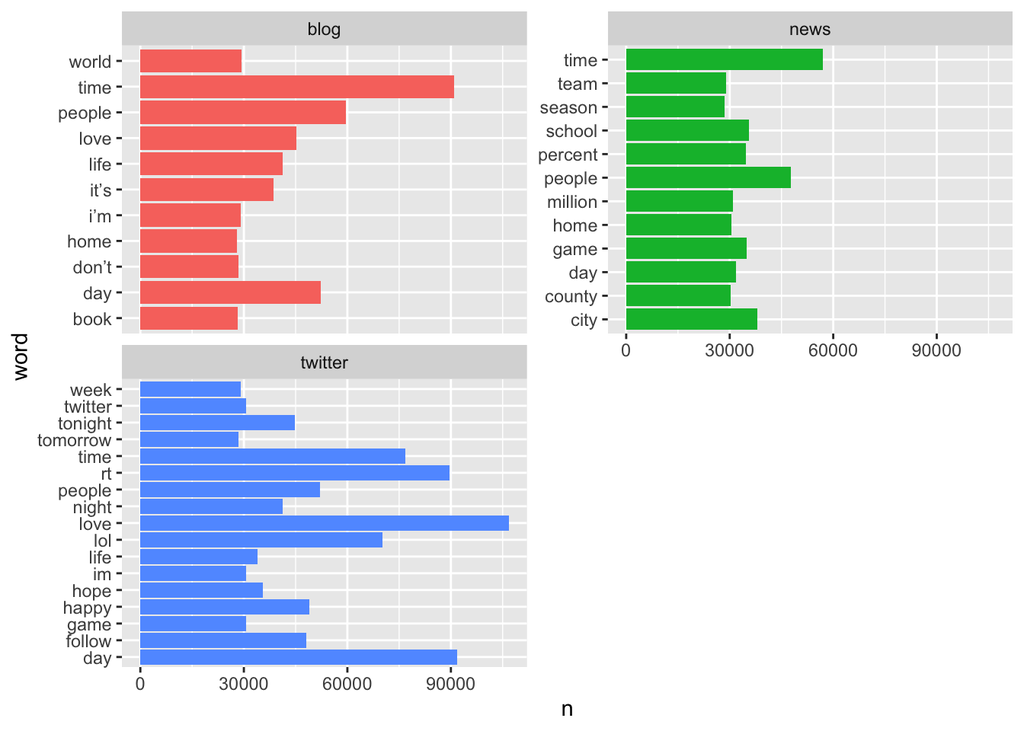

```r
corpus_words <- corpus %>%
        unnest_tokens(word, text) %>%
        filter(!grepl('[0-9]', word)) %>%
        anti_join(stop_words) %>%
        anti_join(remove_words) %>%
        count(source, word, sort = TRUE)

corpus_words %>%
        group_by(source) %>%
        filter(n > 27500) %>%
        arrange(desc(n)) %>%
        ggplot(aes(n, word, fill = source)) +
        geom_col(show.legend = FALSE) +
        facet_wrap(~source, ncol = 2, scales = "free_y")
```

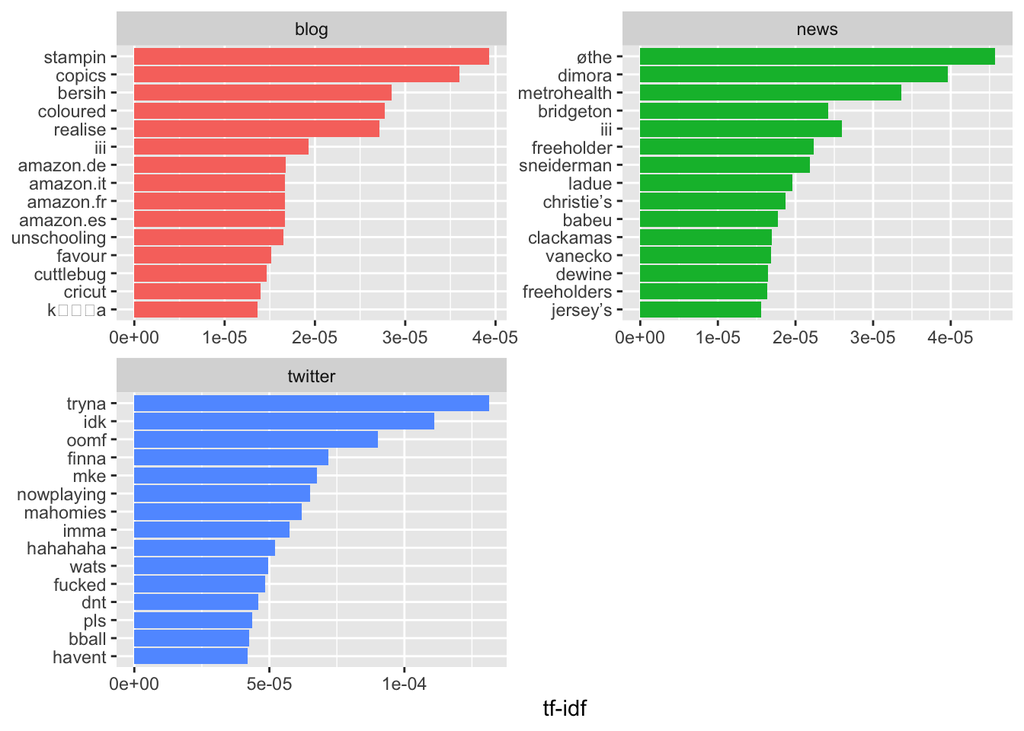

```r
corpus_total <- corpus_words %>%
        group_by(source) %>%
        summarize(total = sum(n))

corpus_words <- left_join(corpus_words, corpus_total)

source_tf_idf <- corpus_words %>%
        bind_tf_idf(word, source, n) %>%
        select(-total) %>%
        arrange(desc(tf_idf))

source_tf_idf %>%
        group_by(source) %>%
        slice_max(tf_idf, n = 15) %>%
        ungroup() %>%
        ggplot(aes(tf_idf, fct_reorder(word, tf_idf), fill = source)) +
        geom_col(show.legend = FALSE) +
        facet_wrap(~source, ncol = 2, scales = "free") +
        labs(x = "tf-idf", y = NULL)
```

```r
rm(source_tf_idf)
invisible(gc(verbose = FALSE, reset = TRUE))
```

I then conducted a tf-idf analysis to determine the most important words in each data set. The three sources varied widely in most important words, with little in common. The three most important words in the Blogs data were stampin, copics, and bersih. In the News data, they were øthe, dimora, and metrohealth and in the Twitter data, tryna, idk, and oomf.

## N-grams

The heart of my predictive model will be bigrams and trigrams. Accordingly, I constructed bi- and trigrams to examine the relationships between words in the body of my data using Markov chains. As always, I first removed all numbers, profanity, and racist terms from my data. I then selected a random sample containing 10% of the total data to speed up the analysis.

```r
set.seed(5621)
bigrams <- corpus %>%
        unnest_tokens(bigram, text, token = "ngrams", n = 2)
bigrams_sample <- bigrams[sample(nrow(bigrams), size = round(nrow(bigrams)/10), replace = FALSE), ] %>%
        separate(bigram, c("word1", "word2"), sep = " ") %>%
        filter(!grepl('[0-9]', word1),
               !grepl('[0-9]', word2)) %>%
        filter(!word1 %in% stop_words$word,
               !word2 %in% stop_words$word) %>%
        filter(!word1 %in% remove_words$word,
               !word2 %in% remove_words$word) %>%
        count(word1, word2, sort = TRUE)
rm(bigrams)
invisible(gc(verbose = FALSE, reset = TRUE))

trigrams <- corpus %>%
        unnest_tokens(trigram, text, token = "ngrams", n = 3)
trigrams_sample <- trigrams[sample(nrow(trigrams), size = round(nrow(trigrams)/10), replace = FALSE), ] %>%
        separate(trigram, c("word1", "word2", "word3"), sep = " ") %>%
        filter(!grepl('[0-9]', word1),
               !grepl('[0-9]', word2),
               !grepl('[0-9]', word3)) %>%
        filter(!word1 %in% stop_words$word,
               !word2 %in% stop_words$word,
               !word3 %in% stop_words$word) %>%
        filter(!word1 %in% remove_words$word,
               !word2 %in% remove_words$word,
               !word3 %in% remove_words$word) %>%
        count(word1, word2, word3, sort = TRUE)
rm(trigrams)
invisible(gc(verbose = FALSE, reset = TRUE))
```

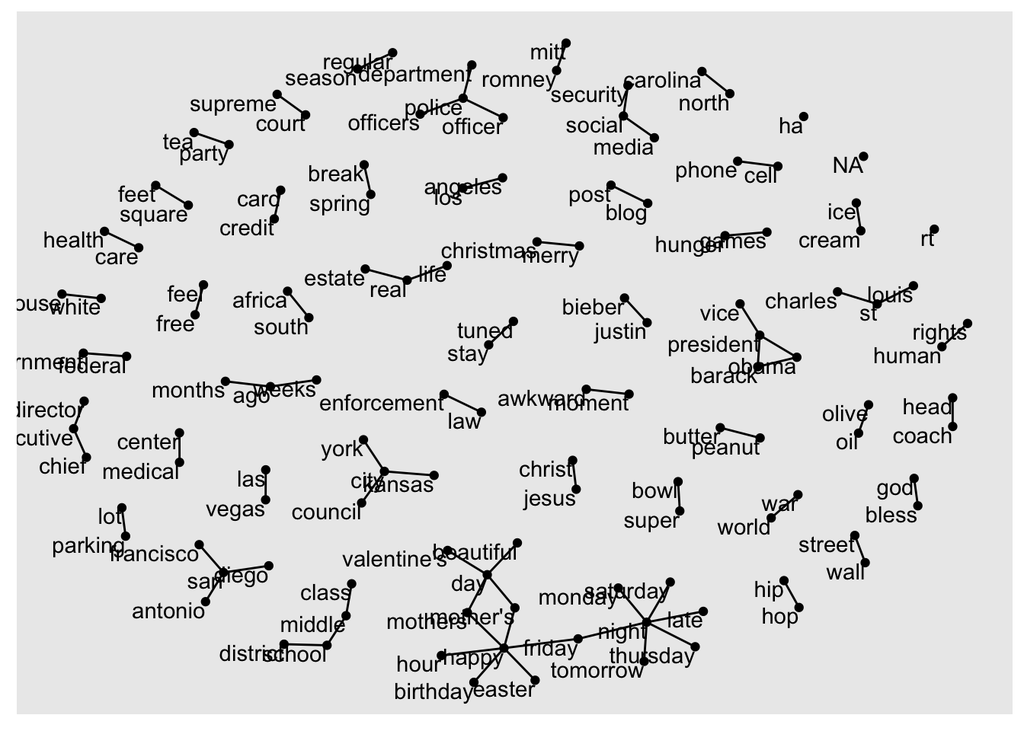

```r
bigram_graph <- bigrams_sample %>%
        filter(n > 150) %>%
        graph_from_data_frame()
library(ggraph)
set.seed(2021)
ggraph(bigram_graph, layout = "fr") +
        geom_edge_link() +
        geom_node_point() +
        geom_node_text(aes(label = name), vjust = 1, hjust = 1)
```

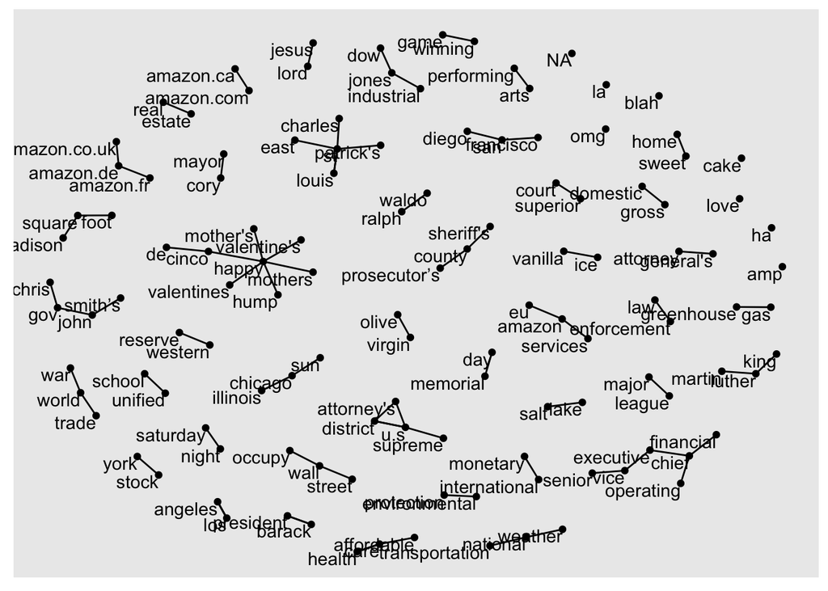

```r
trigram_graph <- trigrams_sample %>%
        filter(n > 20) %>%
        graph_from_data_frame()
set.seed(2021)
ggraph(trigram_graph, layout = "fr") +
        geom_edge_link() +
        geom_node_point() +
        geom_node_text(aes(label = name), vjust = 1, hjust = 1)
```

We see that “happy” is still associated with “mother’s” but now we also see “valentine’s”, “hump” and “cinco”. “major” is paired with “league” whereas “martin”, “luther”, and “king” run together.

## Future plans

The final form of this project will be a Shiny app with a user interface wherein the user may supply a word or phrase and then have the next word predicted, with up to three options given. The predictive model will be based on the Markov chains visualized in the last two graphs. The biggest issue will be computational space. To be useful, the Markov chain should be based on as much of the underlying data as possible. I’ve already run into memory issues while developing this report as I initially attempted to use the full corpus and had to cut my sample down. Computational limits will be even more severe for a web-based app.